# DatSaurus 2025

## Resumen estadístico de CIRCLE

En esta parte, lo que realizamos es separar solo el dataset circle y obtener las estadísticas del mismo. Así, podemos identificar algunas métricas como la media, varianza y desviación estándar. En sí, es lo mismo en cuanto a datos estadísticos que los otros subgrupos.

```r
datasaurus_dozen %>%
  filter(dataset == "circle") %>%
  summarize(
    mean_x = mean(x),
    mean_y = mean(y),
    std_dev_x = sd(x),
    std_dev_y = sd(y),
    corr_x_y = cor(x, y)
  )
```

```
## # A tibble: 1 × 5
##   mean_x mean_y std_dev_x std_dev_y corr_x_y
##    <dbl>  <dbl>     <dbl>     <dbl>    <dbl>
## 1   54.3   47.8      16.8      26.9  -0.0683
```

## Grafica de CIRCLE

En esta parte, lo que se realiza es mostrar los puntos del dataset circle, para poder visualizar estos datos. Se puede observar que tienen forma de elipse o circunferencia, lo cual no es evidente solo con los valores estadísticos. Usamos la librería ggplot2 para generar el gráfico, lo que nos ayuda a entender la distribución de los datos, que en este caso forma un círculo. De esta manera, podemos complementar el análisis numérico anterior con una visualización que revela la verdadera estructura de los datos, la cual no es evidente únicamente a través de estadísticas.

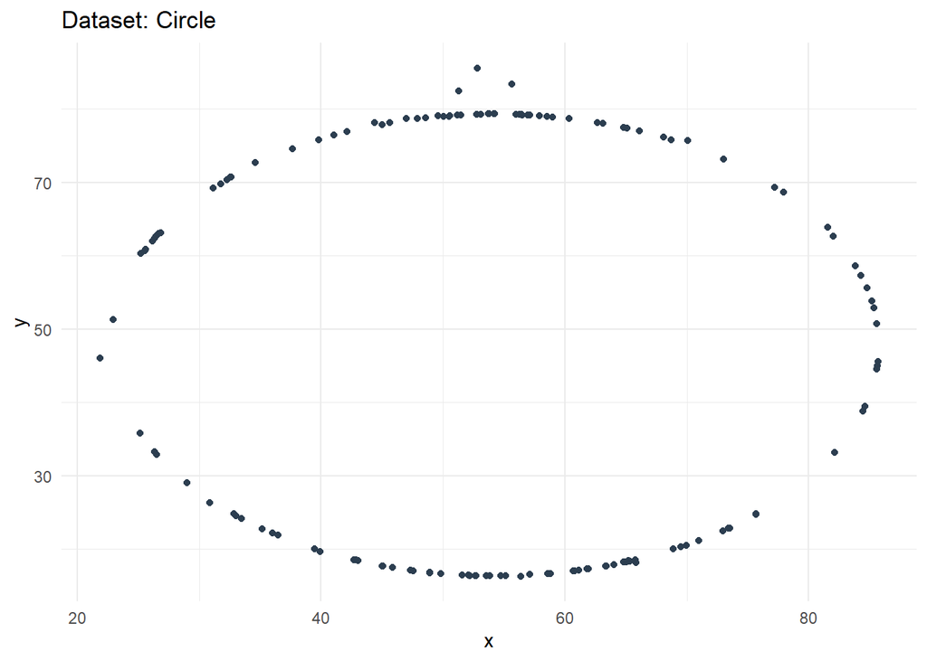

```r
ggplot(filter(datasaurus_dozen, dataset == "circle"), aes(x = x, y = y)) +
  geom_point(color = "#2C3E50") +
  theme_minimal() +
  labs(title = "Dataset: Circle")
```

## Regresión lineal sobre CIRCLE

En esta parte aplicamos una regresión lineal en el dataset circle. Lo que se realizó fue filtrar los datos y luego, con la función lm(), pudimos obtener la recta que mejor se ajusta a los puntos. Luego, con ggplot2, mostramos los puntos y también, en rojo, la línea que representa la regresión lineal. Esto nos sirvió para poder comparar el gráfico que realizamos a mano, solo viendo la forma del círculo sin usar valores numéricos, de tal forma que lo podemos comparar para ver si se parece o no al que hicimos de forma empírica.

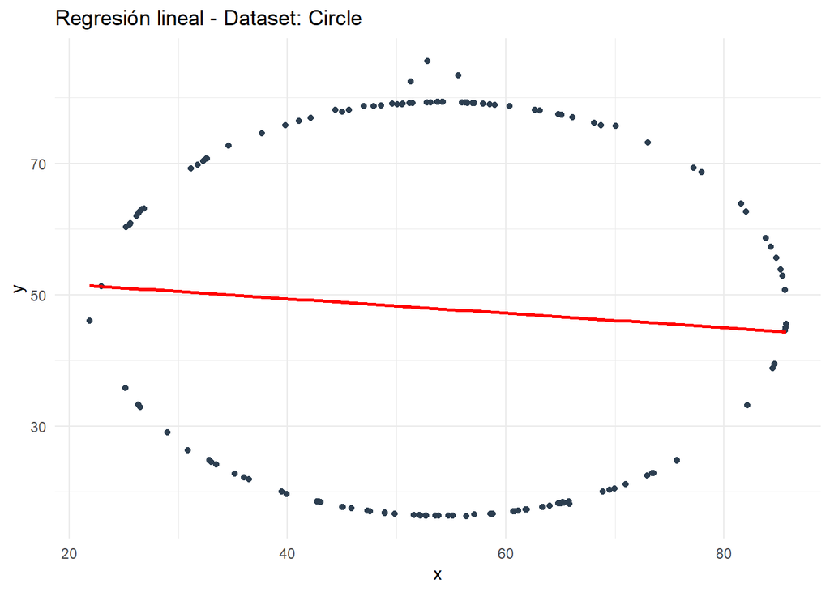

```r
# Filtramos el dataset
circle_data <- datasaurus_dozen %>%
  filter(dataset == "circle")

# Ajustamos el modelo de regresión lineal
modelo <- lm(y ~ x, data = circle_data)

ggplot(circle_data, aes(x = x, y = y)) +
  geom_point(color = "#2C3E50") +
  geom_smooth(method = "lm", se = FALSE, color = "red", linewidth = 1) +
  theme_minimal() +
  labs(title = "Regresión lineal - Dataset: Circle")
```

## Regresión lineal a mano

En esta parte se muestra una imagen del gráfico que realizamos a mano, solo observando la forma que tienen los puntos del dataset circle. Sin usar ninguna fórmula ni valores numéricos, trazamos una línea recta aproximada según lo que creíamos que sería la regresión lineal, basándonos únicamente en la distribución visual de los datos.

Esto nos permitió comparar de forma empírica con la línea generada automáticamente por el modelo lineal y ver si se parecen.

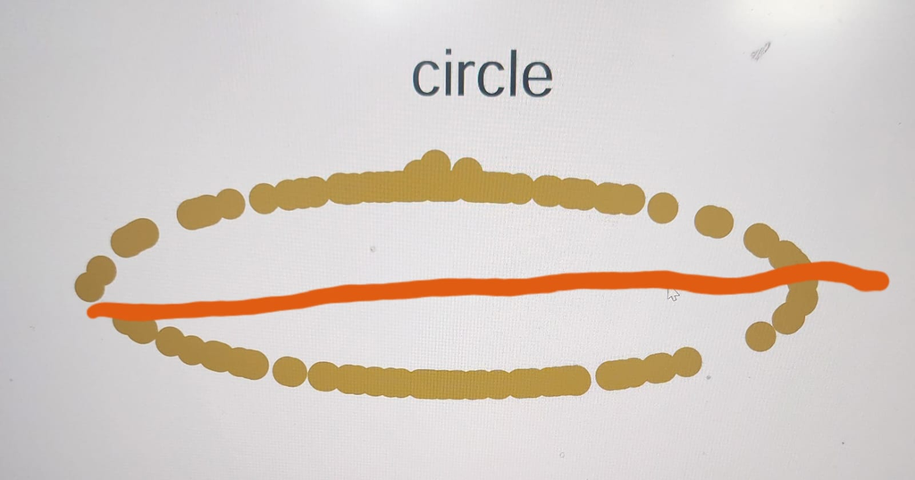

```r
knitr::include_graphics("circlemano.jpeg")
```

## Conclusión

Esta práctica nos permitió entender que, aunque varios conjuntos de datos pueden tener estadísticas similares, su forma visual puede ser completamente distinta. Por eso, siempre es importante complementar el análisis numérico con gráficos para obtener una mejor interpretación.